# HelmNet: Full-code Submission — SafeGuard Corp

**Objective:** Build a robust image classifier that detects **With Helmet** vs **Without Helmet** for automated site safety monitoring.

## Business Context

Workplace safety in hazardous environments like construction sites and industrial plants is crucial to prevent accidents and injuries. One of the most important safety measures is ensuring workers wear safety helmets, which protect against head injuries from falling objects and machinery. Non-compliance with helmet regulations increases the risk of serious injuries or fatalities, making effective monitoring essential, especially in large-scale operations where manual oversight is prone to errors and inefficiency.

To overcome these challenges, SafeGuard Corp plans to develop an automated image analysis system to detect whether workers are wearing safety helmets. This system will improve safety enforcement, ensuring compliance and reducing the risk of head injuries. By automating helmet monitoring, SafeGuard aims to enhance efficiency, scalability, and accuracy, ultimately fostering a safer work environment while minimizing human error in safety oversight.

## Installing and Importing Necessary Libraries

> **Note:** After executing the install cell in Colab, *restart runtime* and then run all subsequent cells.

```python
!pip install tensorflow[and-cuda] numpy==1.25.2 -q
import tensorflow as tf
print("Num GPUs Available:", len(tf.config.list_physical_devices('GPU')))
print(tf.__version__)
# Note:
# After running the above cell, kindly restart the notebook runtime (in Google Colab) and run all cells sequentially from the next cell.
# On executing the above line of code, you might see a warning regarding package dependencies.
# This can be ignored because the above ensures all required libraries are installed to execute this notebook successfully.
```

[output not shown]

```python
import os
import random
import numpy as np                                                                               # Importing numpy for Matrix Operations
import pandas as pd
import seaborn as sns
import matplotlib.image as mpimg                                                                  # Importing pandas to read CSV files
import matplotlib.pyplot as plt                                                                  # Importting matplotlib for Plotting and visualizing images
import math                                                                                      # Importing math module to perform mathematical operations
import cv2

# Tensorflow modules
import keras
import tensorflow as tf
from tensorflow.keras.preprocessing.image import ImageDataGenerator                              # Importing the ImageDataGenerator for data augmentation
from tensorflow.keras.models import Sequential                                                   # Importing the sequential module to define a sequential model
from tensorflow.keras.layers import Dense,Dropout,Flatten,Conv2D,MaxPooling2D,BatchNormalization # Defining all the layers to build our CNN Model
from tensorflow.keras.optimizers import Adam,SGD                                                 # Importing the optimizers which can be used in our model
from sklearn import preprocessing                                                                # Importing the preprocessing module to preprocess the data
from sklearn.model_selection import train_test_split                                             # Importing train_test_split function to split the data into train and test
from sklearn.metrics import confusion_matrix
from tensorflow.keras.models import Model
from keras.applications.vgg16 import VGG16                                                       # VGG16 base
# Display images using OpenCV
from google.colab.patches import cv2_imshow

# Imports functions for evaluating the performance of ML models
from sklearn.metrics import confusion_matrix, f1_score, accuracy_score, recall_score, precision_score, classification_report
from sklearn.metrics import mean_squared_error as mse

# Ignore warnings
import warnings
warnings.filterwarnings('ignore')

# Set the seed using keras.utils.set_random_seed. This will set numpy, backend, and python seeds.
tf.keras.utils.set_random_seed(812)
```

## Data Overview

We'll load the provided arrays and labels, verify shapes, and preview the distribution.

```python
IMAGES_PATH = "/content/images_proj.npy"
LABELS_PATH = "/content/Labels_proj.csv"

# I had an issue loading the .npy data set so I defaulted to the gemini generated code to write an "If not" statement to load the .npy and .csv files correctly.
if not os.path.exists(IMAGES_PATH) and os.path.exists("/mnt/data/images_proj.npy"):
    IMAGES_PATH = "/mnt/data/images_proj.npy"
if not os.path.exists(LABELS_PATH) and os.path.exists("/mnt/data/Labels_proj.csv"):
    LABELS_PATH = "/mnt/data/Labels_proj.csv"

# Loading the datasets
images = np.load(IMAGES_PATH, allow_pickle=True)
labels_df = pd.read_csv(LABELS_PATH)

# Normalize to a single 'label' column with 0/1
def normalize_labels(df):

    lab_col = None
    for c in df.columns:
        if c.lower() in ("label","labels","target","class","y"):
            lab_col = c
            break
    if lab_col is None:
        lab_col = df.columns[-1]  # fallback

    y_raw = df[lab_col].values
    if y_raw.dtype == object:
        uniq = pd.unique(y_raw)
        mapping = {}
        for v in uniq:
            vs = str(v).strip().lower()
            if "with" in vs and "helmet" in vs:
                mapping[v] = 1
            elif "without" in vs and "helmet" in vs:
                mapping[v] = 0
        if len(mapping) < len(uniq):
            remaining = [v for v in uniq if v not in mapping]
            for i, v in enumerate(sorted(remaining, key=lambda z: str(z))):
                mapping[v] = 1 if i==0 else 0
        y = np.array([mapping.get(v, 0) for v in y_raw], dtype=np.int64)
    else:
        vals = np.unique(y_raw)
        if set(vals.tolist()) == {0,1}:
            y = y_raw.astype(np.int64)
        else:
            thr = np.median(y_raw)
            y = (y_raw > thr).astype(np.int64)
    return y

y = normalize_labels(labels_df)
class_names = {0: "Without Helmet", 1: "With Helmet"}

print("Images shape:", images.shape)
print("Labels shape:", y.shape)
assert len(images) == len(y), "Image and label counts must match"
print("\nLabel counts:", pd.Series(y).value_counts().sort_index().to_dict())
```

```
Images shape: (631, 200, 200, 3)
Labels shape: (631,)

Label counts: {0: 320, 1: 311}
```

## Exploratory Data Analysis (EDA)

- Plot random images from each class with their labels.
- Check for class imbalance.
- Note observations that may inform modeling choices (e.g., lighting, angles).

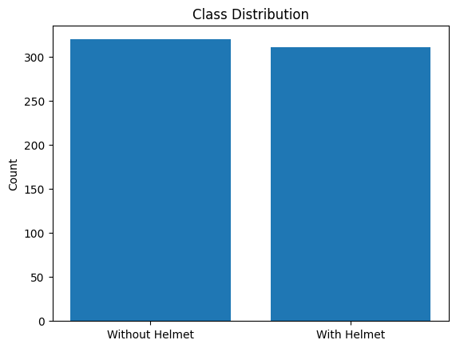

[figure not shown]

```python
# Class Distribution by using value counts and indexing. Additionally for more "robutness" and accurate depictions of the data I wrote a def to get random samples of the dataset.
counts = pd.Series(y).value_counts().sort_index()
plt.figure()
plt.bar([class_names[i] for i in counts.index], counts.values)
plt.title("Class Distribution")
plt.ylabel("Count")
plt.show()

# Random samples
def get_random_indices_for_class(cls, n=4):
    idx = np.where(y == cls)[0]
    if len(idx) == 0:
        return []
    n = min(n, len(idx))
    return np.random.choice(idx, size=n, replace=False)

idxs_0 = get_random_indices_for_class(0, 4)
idxs_1 = get_random_indices_for_class(1, 4)
fig, axes = plt.subplots(2, 4, figsize=(10,5))
axes = axes.ravel()

#enumerating indexes
for i, idx in enumerate(idxs_0):
    axes[i].imshow(images[idx] if images[idx].ndim==3 else images[idx], cmap=None if images[idx].ndim==3 else "gray")
    axes[i].set_title(f"Without Helmet (idx={idx})")
    axes[i].axis("off")

for j, idx in enumerate(idxs_1):
    axes[j+4].imshow(images[idx] if images[idx].ndim==3 else images[idx], cmap=None if images[idx].ndim==3 else "gray")
    axes[j+4].set_title(f"With Helmet (idx={idx})")
    axes[j+4].axis("off")

fig.suptitle("Random Samples by Class", y=1.02)
plt.tight_layout()
plt.show()
```

## Data Pre-processing

- Convert RGB to Grayscale (reduces channels).
- Normalize to [0,1].
- Stratified Train/Val/Test split.

```python
#Normalizing and stratifying the dataset using train_test_split from the sklearn library

#Creating Grey Scale Tensor
def to_gray(img):
    if img.ndim == 2:
        return img
    try:
        import cv2
        if img.shape[2]==3:
            return cv2.cvtColor(img, cv2.COLOR_BGR2GRAY)
        elif img.shape[2]==4:
            return cv2.cvtColor(img, cv2.COLOR_BGRA2GRAY)
    except Exception:
        pass
    if img.ndim==3 and img.shape[2]>=3:
        r,g,b = img[...,0], img[...,1], img[...,2]
        return (0.2989*r + 0.5870*g + 0.1140*b).astype(img.dtype)
    return img[...,0]

gray_images = np.stack([to_gray(im) for im in images], axis=0).astype("float32")
if gray_images.max() > 1.0:
    gray_images /= 255.0
X_gray = np.expand_dims(gray_images, axis=-1)
print("Grayscale tensor:", X_gray.shape, X_gray.dtype)
```

```
Grayscale tensor: (631, 200, 200, 1) float32
```

```
Train: (441, 200, 200, 1)  Val: (95, 200, 200, 1)  Test: (95, 200, 200, 1)
```

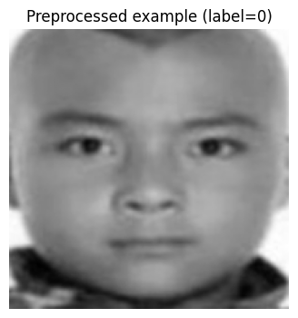

```python
from sklearn.model_selection import train_test_split
X_train, X_temp, y_train, y_temp = train_test_split(
    X_gray, y, test_size=0.3, stratify=y, random_state=812
)
X_val, X_test, y_val, y_test = train_test_split(
    X_temp, y_temp, test_size=0.5, stratify=y_temp, random_state=812
)
print("Train:", X_train.shape, " Val:", X_val.shape, " Test:", X_test.shape)

# Quick preview
idx = np.random.randint(0, len(X_train))
plt.figure(figsize=(4,4))
plt.imshow(X_train[idx].squeeze(), cmap="gray")
plt.title(f"Preprocessed example (label={y_train[idx]})")
plt.axis("off")
plt.show()
```

## Basic Convolutional Neural Network

We start with a small CNN on grayscale input. Comments describe key choices.

```python
#CNN Architecture creation (Convolutions/Maxpooling/BatchNormalizatioins)
def build_basic_cnn(input_shape):
    model = Sequential([
        Conv2D(16, (3,3), activation='relu', padding='same', input_shape=input_shape),
        MaxPooling2D((2,2)),
        BatchNormalization(),

        Conv2D(32, (3,3), activation='relu', padding='same'),
        MaxPooling2D((2,2)),
        BatchNormalization(),

        Flatten(),
        Dense(64, activation='relu'),
        Dropout(0.3),
        Dense(1, activation='sigmoid')
    ])
    model.compile(optimizer=Adam(1e-3), loss='binary_crossentropy', metrics=['accuracy'])
    return model

basic_cnn = build_basic_cnn(X_train.shape[1:])
basic_cnn.summary()
```

```
Model: "sequential"
```

```
┏━━━━━━━━━━━━━━━━━━━━━━━━━━━━━━━━━┳━━━━━━━━━━━━━━━━━━━━━━━━┳━━━━━━━━━━━━━━━┓
┃ Layer (type)                    ┃ Output Shape           ┃       Param # ┃
┡━━━━━━━━━━━━━━━━━━━━━━━━━━━━━━━━━╇━━━━━━━━━━━━━━━━━━━━━━━━╇━━━━━━━━━━━━━━━┩
│ conv2d (Conv2D)                 │ (None, 200, 200, 16)   │           160 │
├─────────────────────────────────┼────────────────────────┼───────────────┤
│ max_pooling2d (MaxPooling2D)    │ (None, 100, 100, 16)   │             0 │
├─────────────────────────────────┼────────────────────────┼───────────────┤
│ batch_normalization             │ (None, 100, 100, 16)   │            64 │
│ (BatchNormalization)            │                        │               │
├─────────────────────────────────┼────────────────────────┼───────────────┤
│ conv2d_1 (Conv2D)               │ (None, 100, 100, 32)   │         4,640 │
├─────────────────────────────────┼────────────────────────┼───────────────┤
│ max_pooling2d_1 (MaxPooling2D)  │ (None, 50, 50, 32)     │             0 │
├─────────────────────────────────┼────────────────────────┼───────────────┤
│ batch_normalization_1           │ (None, 50, 50, 32)     │           128 │
│ (BatchNormalization)            │                        │               │
├─────────────────────────────────┼────────────────────────┼───────────────┤
│ flatten (Flatten)               │ (None, 80000)          │             0 │
├─────────────────────────────────┼────────────────────────┼───────────────┤
│ dense (Dense)                   │ (None, 64)             │     5,120,064 │
├─────────────────────────────────┼────────────────────────┼───────────────┤
│ dropout (Dropout)               │ (None, 64)             │             0 │
├─────────────────────────────────┼────────────────────────┼───────────────┤
│ dense_1 (Dense)                 │ (None, 1)              │            65 │
└─────────────────────────────────┴────────────────────────┴───────────────┘
```

```
 Total params: 5,125,121 (19.55 MB)
```

```
 Trainable params: 5,125,025 (19.55 MB)
```

```
 Non-trainable params: 96 (384.00 B)
```

```python
#Model Ffitting
history_basic = basic_cnn.fit(
    X_train, y_train,
    validation_data=(X_val, y_val),
    epochs=8,
    batch_size=32,
    verbose=1
)
```

```
14/14 ━━━━━━━━━━━━━━━━━━━━ 37s 2s/step - accuracy: 0.8732 - loss: 1.7053 - val_accuracy: 0.5263 - val_loss: 0.6938
14/14 ━━━━━━━━━━━━━━━━━━━━ 26s 1s/step - accuracy: 0.9828 - loss: 0.2728 - val_accuracy: 0.6947 - val_loss: 0.7049
14/14 ━━━━━━━━━━━━━━━━━━━━ 20s 1s/step - accuracy: 0.9878 - loss: 0.0918 - val_accuracy: 0.5053 - val_loss: 3.2267
14/14 ━━━━━━━━━━━━━━━━━━━━ 21s 1s/step - accuracy: 0.9912 - loss: 0.1031 - val_accuracy: 0.5053 - val_loss: 3.4462
14/14 ━━━━━━━━━━━━━━━━━━━━ 16s 1s/step - accuracy: 0.9961 - loss: 0.0488 - val_accuracy: 0.5053 - val_loss: 4.4746
14/14 ━━━━━━━━━━━━━━━━━━━━ 14s 992ms/step - accuracy: 1.0000 - loss: 2.6928e-04 - val_accuracy: 0.5053 - val_loss: 6.6392
14/14 ━━━━━━━━━━━━━━━━━━━━ 14s 1s/step - accuracy: 0.9981 - loss: 0.0307 - val_accuracy: 0.5053 - val_loss: 7.3912
14/14 ━━━━━━━━━━━━━━━━━━━━ 14s 1s/step - accuracy: 1.0000 - loss: 1.7879e-06 - val_accuracy: 0.5053 - val_loss: 7.6141
```

```
Validation Accuracy (Basic CNN): 0.5053
```

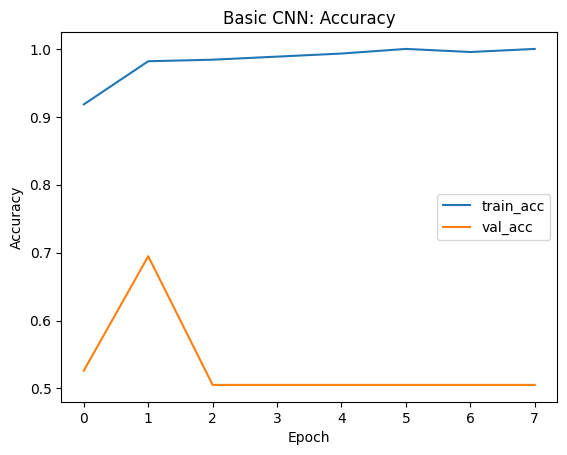

```python
val_loss, val_acc = basic_cnn.evaluate(X_val, y_val, verbose=0)
print(f"Validation Accuracy (Basic CNN): {val_acc:.4f}")
plt.figure()
plt.plot(history_basic.history['accuracy'], label='train_acc')
plt.plot(history_basic.history['val_accuracy'], label='val_acc')
plt.title('Basic CNN: Accuracy')
plt.xlabel('Epoch')
plt.ylabel('Accuracy')
plt.legend()
plt.show()
```

## VGG‑16 (Transfer Learning)

```python
#def creation that takes an image tensor (x) as the input and prepares it for use with the VGG16 model that was created
def to_vgg_input(x):
    x3 = tf.image.grayscale_to_rgb(tf.convert_to_tensor(x))
    x3 = tf.image.resize(x3, (224, 224))
    return x3.numpy()

X_train_vgg = to_vgg_input(X_train)
X_val_vgg   = to_vgg_input(X_val)
X_test_vgg  = to_vgg_input(X_test)
print("VGG input shapes:", X_train_vgg.shape, X_val_vgg.shape, X_test_vgg.shape)
```

```
VGG input shapes: (441, 224, 224, 3) (95, 224, 224, 3) (95, 224, 224, 3)
```

```python
#creating a vgg16 based cnn for image classifcation
def build_vgg16_model(input_shape=(224,224,3), weights='imagenet', train_base=False):
    base = VGG16(include_top=False, weights=weights, input_shape=input_shape)
    base.trainable = train_base
    x = tf.keras.layers.GlobalAveragePooling2D()(base.output)
    x = tf.keras.layers.Dense(128, activation='relu')(x)
    x = tf.keras.layers.Dropout(0.3)(x)
    out = tf.keras.layers.Dense(1, activation='sigmoid')(x)
    model = tf.keras.Model(inputs=base.input, outputs=out)
    model.compile(optimizer=Adam(1e-4), loss='binary_crossentropy', metrics=['accuracy'])
    return model

vgg16_model = build_vgg16_model(weights='imagenet', train_base=False)
vgg16_model.summary()
```

```
Model: "functional_1"
```

```
┏━━━━━━━━━━━━━━━━━━━━━━━━━━━━━━━━━┳━━━━━━━━━━━━━━━━━━━━━━━━┳━━━━━━━━━━━━━━━┓
┃ Layer (type)                    ┃ Output Shape           ┃       Param # ┃
┡━━━━━━━━━━━━━━━━━━━━━━━━━━━━━━━━━╇━━━━━━━━━━━━━━━━━━━━━━━━╇━━━━━━━━━━━━━━━┩
│ input_layer_1 (InputLayer)      │ (None, 224, 224, 3)    │             0 │
├─────────────────────────────────┼────────────────────────┼───────────────┤
│ block1_conv1 (Conv2D)           │ (None, 224, 224, 64)   │         1,792 │
├─────────────────────────────────┼────────────────────────┼───────────────┤
│ block1_conv2 (Conv2D)           │ (None, 224, 224, 64)   │        36,928 │
├─────────────────────────────────┼────────────────────────┼───────────────┤
│ block1_pool (MaxPooling2D)      │ (None, 112, 112, 64)   │             0 │
├─────────────────────────────────┼────────────────────────┼───────────────┤
│ block2_conv1 (Conv2D)           │ (None, 112, 112, 128)  │        73,856 │
├─────────────────────────────────┼────────────────────────┼───────────────┤
│ block2_conv2 (Conv2D)           │ (None, 112, 112, 128)  │       147,584 │
├─────────────────────────────────┼────────────────────────┼───────────────┤
│ block2_pool (MaxPooling2D)      │ (None, 56, 56, 128)    │             0 │
├─────────────────────────────────┼────────────────────────┼───────────────┤
│ block3_conv1 (Conv2D)           │ (None, 56, 56, 256)    │       295,168 │
├─────────────────────────────────┼────────────────────────┼───────────────┤
│ block3_conv2 (Conv2D)           │ (None, 56, 56, 256)    │       590,080 │
├─────────────────────────────────┼────────────────────────┼───────────────┤
│ block3_conv3 (Conv2D)           │ (None, 56, 56, 256)    │       590,080 │
├─────────────────────────────────┼────────────────────────┼───────────────┤
│ block3_pool (MaxPooling2D)      │ (None, 28, 28, 256)    │             0 │
├─────────────────────────────────┼────────────────────────┼───────────────┤
│ block4_conv1 (Conv2D)           │ (None, 28, 28, 512)    │     1,180,160 │
├─────────────────────────────────┼────────────────────────┼───────────────┤
│ block4_conv2 (Conv2D)           │ (None, 28, 28, 512)    │     2,359,808 │
├─────────────────────────────────┼────────────────────────┼───────────────┤
│ block4_conv3 (Conv2D)           │ (None, 28, 28, 512)    │     2,359,808 │
├─────────────────────────────────┼────────────────────────┼───────────────┤
│ block4_pool (MaxPooling2D)      │ (None, 14, 14, 512)    │             0 │
├─────────────────────────────────┼────────────────────────┼───────────────┤
│ block5_conv1 (Conv2D)           │ (None, 14, 14, 512)    │     2,359,808 │
├─────────────────────────────────┼────────────────────────┼───────────────┤
│ block5_conv2 (Conv2D)           │ (None, 14, 14, 512)    │     2,359,808 │
├─────────────────────────────────┼────────────────────────┼───────────────┤
│ block5_conv3 (Conv2D)           │ (None, 14, 14, 512)    │     2,359,808 │
├─────────────────────────────────┼────────────────────────┼───────────────┤
│ block5_pool (MaxPooling2D)      │ (None, 7, 7, 512)      │             0 │
├─────────────────────────────────┼────────────────────────┼───────────────┤
│ global_average_pooling2d        │ (None, 512)            │             0 │
│ (GlobalAveragePooling2D)        │                        │               │
├─────────────────────────────────┼────────────────────────┼───────────────┤
│ dense_2 (Dense)                 │ (None, 128)            │        65,664 │
├─────────────────────────────────┼────────────────────────┼───────────────┤
│ dropout_1 (Dropout)             │ (None, 128)            │             0 │
├─────────────────────────────────┼────────────────────────┼───────────────┤
│ dense_3 (Dense)                 │ (None, 1)              │           129 │
└─────────────────────────────────┴────────────────────────┴───────────────┘
```

```
 Total params: 14,780,481 (56.38 MB)
```

```
 Trainable params: 65,793 (257.00 KB)
```

```
 Non-trainable params: 14,714,688 (56.13 MB)
```

```python
history_vgg = vgg16_model.fit(
    X_train_vgg, y_train,
    validation_data=(X_val_vgg, y_val),
    epochs=6,
    batch_size=32,
    verbose=1
)
val_loss_vgg, val_acc_vgg = vgg16_model.evaluate(X_val_vgg, y_val, verbose=0)
print(f"Validation Accuracy (VGG16): {val_acc_vgg:.4f}")
```

```
14/14 ━━━━━━━━━━━━━━━━━━━━ 310s 22s/step - accuracy: 0.5015 - loss: 0.6932 - val_accuracy: 0.5053 - val_loss: 0.6930
14/14 ━━━━━━━━━━━━━━━━━━━━ 286s 20s/step - accuracy: 0.5684 - loss: 0.6930 - val_accuracy: 0.5684 - val_loss: 0.6930
14/14 ━━━━━━━━━━━━━━━━━━━━ 273s 20s/step - accuracy: 0.5666 - loss: 0.6930 - val_accuracy: 0.6632 - val_loss: 0.6929
14/14 ━━━━━━━━━━━━━━━━━━━━ 307s 22s/step - accuracy: 0.5806 - loss: 0.6930 - val_accuracy: 0.7684 - val_loss: 0.6928
14/14 ━━━━━━━━━━━━━━━━━━━━ 322s 22s/step - accuracy: 0.6342 - loss: 0.6928 - val_accuracy: 0.7895 - val_loss: 0.6928
14/14 ━━━━━━━━━━━━━━━━━━━━ 309s 22s/step - accuracy: 0.6491 - loss: 0.6929 - val_accuracy: 0.7579 - val_loss: 0.6927
Validation Accuracy (VGG16): 0.7579
```

## VGG‑16 with FFNN

We add a deeper head (two dense layers) on top of VGG16 features.

```python
#deeper classifcation head (two pretty dense layers compared to the previous model.)
def build_vgg16_ffnn(input_shape=(224,224,3), weights='imagenet', train_base=False):
    base = VGG16(include_top=False, weights=weights, input_shape=input_shape)
    base.trainable = train_base
    x = tf.keras.layers.GlobalAveragePooling2D()(base.output)
    x = tf.keras.layers.Dense(256, activation='relu')(x)
    x = tf.keras.layers.Dropout(0.4)(x)
    x = tf.keras.layers.Dense(64, activation='relu')(x)
    x = tf.keras.layers.Dropout(0.3)(x)
    out = tf.keras.layers.Dense(1, activation='sigmoid')(x)
    model = tf.keras.Model(inputs=base.input, outputs=out)
    model.compile(optimizer=Adam(1e-4), loss='binary_crossentropy', metrics=['accuracy'])
    return model

vgg16_ffnn = build_vgg16_ffnn(weights='imagenet', train_base=False)
history_vgg_ffnn = vgg16_ffnn.fit(
    X_train_vgg, y_train,
    validation_data=(X_val_vgg, y_val),
    epochs=6,
    batch_size=32,
    verbose=1
)
val_loss_vggf, val_acc_vggf = vgg16_ffnn.evaluate(X_val_vgg, y_val, verbose=0)
print(f"Validation Accuracy (VGG16+FFNN): {val_acc_vggf:.4f}")
```

```
14/14 ━━━━━━━━━━━━━━━━━━━━ 310s 22s/step - accuracy: 0.4999 - loss: 0.6932 - val_accuracy: 0.5053 - val_loss: 0.6931
14/14 ━━━━━━━━━━━━━━━━━━━━ 321s 22s/step - accuracy: 0.5394 - loss: 0.6931 - val_accuracy: 0.5053 - val_loss: 0.6931
14/14 ━━━━━━━━━━━━━━━━━━━━ 323s 22s/step - accuracy: 0.5452 - loss: 0.6930 - val_accuracy: 0.5053 - val_loss: 0.6930
14/14 ━━━━━━━━━━━━━━━━━━━━ 289s 20s/step - accuracy: 0.5858 - loss: 0.6930 - val_accuracy: 0.5053 - val_loss: 0.6929
14/14 ━━━━━━━━━━━━━━━━━━━━ 358s 23s/step - accuracy: 0.6168 - loss: 0.6929 - val_accuracy: 0.5053 - val_loss: 0.6929
14/14 ━━━━━━━━━━━━━━━━━━━━ 275s 20s/step - accuracy: 0.6013 - loss: 0.6929 - val_accuracy: 0.6421 - val_loss: 0.6928
Validation Accuracy (VGG16+FFNN): 0.6421
```

## VGG‑16 with Data Augmentation

Use simple augmentations to increase robustness.

```python
#aug = ImageDataGenerator: This creates an ImageDataGenerator object from Keras, which is used to perform real-time data augmentation on images during the training process.
aug = ImageDataGenerator(
    rotation_range=15,
    width_shift_range=0.1,
    height_shift_range=0.1,
    zoom_range=0.1,
    horizontal_flip=True
)
train_aug = aug.flow(X_train_vgg, y_train, batch_size=32, shuffle=True)

vgg16_aug = build_vgg16_model(weights=None, train_base=False)
history_vgg_aug = vgg16_aug.fit(
    train_aug,
    validation_data=(X_val_vgg, y_val),
    epochs=6,
    verbose=1
)
val_loss_vgga, val_acc_vgga = vgg16_aug.evaluate(X_val_vgg, y_val, verbose=0)
print(f"Validation Accuracy (VGG16+Aug): {val_acc_vgga:.4f}")
```

```
14/14 ━━━━━━━━━━━━━━━━━━━━ 316s 23s/step - accuracy: 0.4715 - loss: 0.6932 - val_accuracy: 0.5053 - val_loss: 0.6931
14/14 ━━━━━━━━━━━━━━━━━━━━ 312s 23s/step - accuracy: 0.5462 - loss: 0.6931 - val_accuracy: 0.5053 - val_loss: 0.6931
14/14 ━━━━━━━━━━━━━━━━━━━━ 279s 20s/step - accuracy: 0.5139 - loss: 0.6931 - val_accuracy: 0.5053 - val_loss: 0.6930
14/14 ━━━━━━━━━━━━━━━━━━━━ 312s 23s/step - accuracy: 0.5970 - loss: 0.6930 - val_accuracy: 0.6105 - val_loss: 0.6929
14/14 ━━━━━━━━━━━━━━━━━━━━ 312s 23s/step - accuracy: 0.6472 - loss: 0.6930 - val_accuracy: 0.6947 - val_loss: 0.6929
14/14 ━━━━━━━━━━━━━━━━━━━━ 317s 23s/step - accuracy: 0.6466 - loss: 0.6929 - val_accuracy: 0.6737 - val_loss: 0.6928
Validation Accuracy (VGG16+Aug): 0.6737
```

## Model Performance Comparison & Final Model Selection

Compare validation metrics, select best model, and evaluate on the test set.

```
Validation Accuracies: {'Basic CNN': 0.5052631497383118, 'VGG16': 0.75789475440979, 'VGG16+FFNN': 0.6421052813529968, 'VGG16+Aug': 0.6736842393875122}
Selected final model: VGG16

Test Accuracy: 0.7789473684210526
Precision: 0.8421052631578947
Recall: 0.6808510638297872
F1: 0.7529411764705882

Classification Report:
                 precision    recall  f1-score   support

Without Helmet       0.74      0.88      0.80        48
   With Helmet       0.84      0.68      0.75        47

      accuracy                           0.78        95
     macro avg       0.79      0.78      0.78        95
  weighted avg       0.79      0.78      0.78        95
```

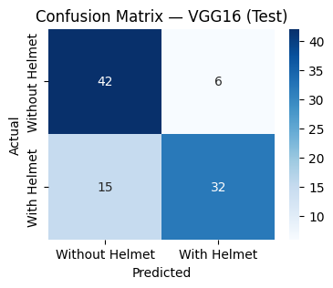

```python
results = {
    "Basic CNN": globals().get("val_acc"),
    "VGG16": globals().get("val_acc_vgg"),
    "VGG16+FFNN": globals().get("val_acc_vggf"),
    "VGG16+Aug": globals().get("val_acc_vgga"),
}
print("Validation Accuracies:", results)

# Picking the best available model
if any(v is not None for v in results.values()):
    best_model_name = max([k for k,v in results.items() if v is not None], key=lambda k: results[k])
else:
    best_model_name = "VGG16+Aug"  # default if not executed

print("Selected final model:", best_model_name)

if best_model_name == "Basic CNN":
    X_test_in, model = X_test, basic_cnn
elif best_model_name == "VGG16":
    X_test_in, model = X_test_vgg, vgg16_model
elif best_model_name == "VGG16+FFNN":
    X_test_in, model = X_test_vgg, vgg16_ffnn
else:
    X_test_in, model = X_test_vgg, vgg16_aug

y_prob = model.predict(X_test_in, verbose=0).ravel()
y_pred = (y_prob >= 0.5).astype(int)

print("\nTest Accuracy:", accuracy_score(y_test, y_pred))
print("Precision:", precision_score(y_test, y_pred))
print("Recall:", recall_score(y_test, y_pred))
print("F1:", f1_score(y_test, y_pred))
print("\nClassification Report:\n", classification_report(y_test, y_pred, target_names=["Without Helmet","With Helmet"]))

cm = confusion_matrix(y_test, y_pred)
plt.figure(figsize=(4,3))
sns.heatmap(cm, annot=True, fmt="d", cmap="Blues", xticklabels=["Without Helmet","With Helmet"], yticklabels=["Without Helmet","With Helmet"])
plt.title(f"Confusion Matrix — {best_model_name} (Test)")
plt.xlabel("Predicted")
plt.ylabel("Actual")
plt.show()
```

## Actionable Insights & Recommendations

For low-confidence detections, a human-in-the-loop review process would help limit false alarms while keeping oversight efficient. Moving forward, the dataset should continue to expand to include tougher scenarios—like dim lighting, occlusions, and back views—to help the model generalize even better. Once finalized, the system can be deployed as something like a REST API or edge-based service and retrained periodically as new footage becomes available.

The main KPIs to monitor would be precision and recall for the “Without Helmet” class, the false-negative rate, and how quickly alerts are reviewed and resolved after being triggered.